# LAB04 - EDA 01

# Faculty of Mathematics and Computer Science,

# University of Science, HCMC

```python
# import basic libraries
import numpy as np
import pandas as pd
import warnings
warnings.filterwarnings('ignore')
```

```python
# import plot libraries
import seaborn as sns
import matplotlib.pyplot as plt
%matplotlib inline
```

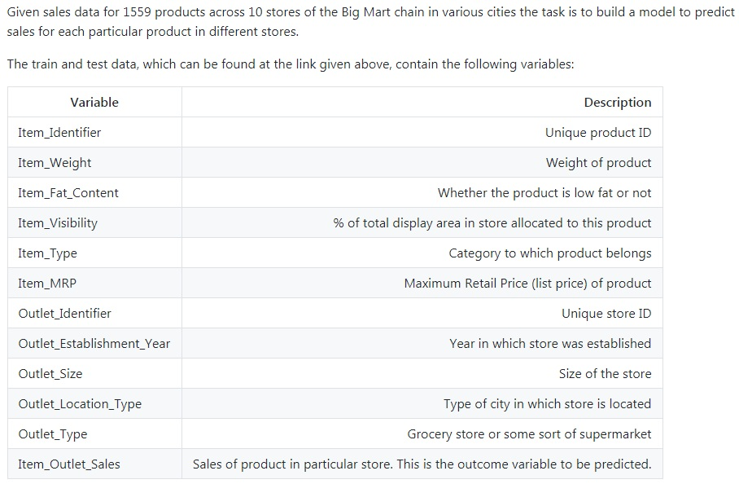

```python
from IPython.display import Image
path = "D:\\MSI DATA (Previous Computer)\\Teaching And Training\\Data Mining\\Lab04 - DM\\"
Image(filename= path + "BigMartSales01.jpg")
```

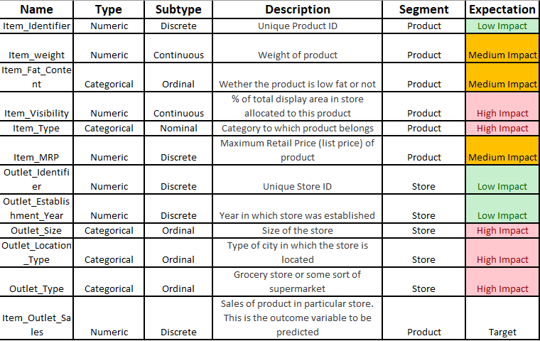

```python
Image(filename= path + "BigMartSales02.png")
```

```python
# Read data
data = pd.read_csv(path + "BigMartSales.csv")
data.head()
```

|  | Item_Identifier | Item_Weight | Item_Fat_Content | Item_Visibility | Item_Type | Item_MRP | Outlet_Identifier | Outlet_Establishment_Year | Outlet_Size | Outlet_Location_Type | Outlet_Type | Item_Outlet_Sales |
| --- | --- | --- | --- | --- | --- | --- | --- | --- | --- | --- | --- | --- |
| 0 | FDA15 | 9.30 | Low Fat | 0.016047 | Dairy | 249.8092 | OUT049 | 1999 | Medium | Tier 1 | Supermarket Type1 | 3735.1380 |
| 1 | DRC01 | 5.92 | Regular | 0.019278 | Soft Drinks | 48.2692 | OUT018 | 2009 | Medium | Tier 3 | Supermarket Type2 | 443.4228 |
| 2 | FDN15 | 17.50 | Low Fat | 0.016760 | Meat | 141.6180 | OUT049 | 1999 | Medium | Tier 1 | Supermarket Type1 | 2097.2700 |
| 3 | FDX07 | 19.20 | Regular | 0.000000 | Fruits and Vegetables | 182.0950 | OUT010 | 1998 | NaN | Tier 3 | Grocery Store | 732.3800 |
| 4 | NCD19 | 8.93 | Low Fat | 0.000000 | Household | 53.8614 | OUT013 | 1987 | High | Tier 3 | Supermarket Type1 | 994.7052 |

**If we look at variable Item_Identifier , we can see different group of letters per each product such as ‘FD’ (Food), ‘DR’(Drinks) and ‘NC’ (Non-Consumable)**

**On the other hand, regarding Item_Visibility there are items with the value zero . This does not make lot of sense, since this is indicating those items are not visible on the store**

```python
data.info()
```

```
<class 'pandas.core.frame.DataFrame'>
RangeIndex: 8523 entries, 0 to 8522
Data columns (total 12 columns):
Item_Identifier              8523 non-null object
Item_Weight                  7060 non-null float64
Item_Fat_Content             8523 non-null object
Item_Visibility              8523 non-null float64
Item_Type                    8523 non-null object
Item_MRP                     8523 non-null float64
Outlet_Identifier            8523 non-null object
Outlet_Establishment_Year    8523 non-null int64
Outlet_Size                  6113 non-null object
Outlet_Location_Type         8523 non-null object
Outlet_Type                  8523 non-null object
Item_Outlet_Sales            8523 non-null float64
dtypes: float64(4), int64(1), object(7)
memory usage: 799.2+ KB
```

Most of the items in the train dataset present 8523 non-null values. However, there are some cases such as Item_Weight and Outlet_Size which seem to present Null values. We always have to consider if this absence of values has a significant meaning. In this case it does not since all values should have weight higher than 0 and a stores cannot exist with zero size.

Moreover, from the 12 features, 5 are numeric and 7 categorical

```python
data.describe()
```

|  | Item_Weight | Item_Visibility | Item_MRP | Outlet_Establishment_Year | Item_Outlet_Sales |
| --- | --- | --- | --- | --- | --- |
| count | 7060.000000 | 8523.000000 | 8523.000000 | 8523.000000 | 8523.000000 |
| mean | 12.857645 | 0.066132 | 140.992782 | 1997.831867 | 2181.288914 |
| std | 4.643456 | 0.051598 | 62.275067 | 8.371760 | 1706.499616 |
| min | 4.555000 | 0.000000 | 31.290000 | 1985.000000 | 33.290000 |
| 25% | 8.773750 | 0.026989 | 93.826500 | 1987.000000 | 834.247400 |
| 50% | 12.600000 | 0.053931 | 143.012800 | 1999.000000 | 1794.331000 |
| 75% | 16.850000 | 0.094585 | 185.643700 | 2004.000000 | 3101.296400 |
| max | 21.350000 | 0.328391 | 266.888400 | 2009.000000 | 13086.964800 |

```python
#Check for duplicates
idsUnique = len(set(data.Item_Identifier))
idsTotal = data.shape[0]
idsDupli = idsTotal - idsUnique
print("There are " + str(idsDupli) + " duplicate IDs for " + str(idsTotal) + " total entries")
```

```
There are 6964 duplicate IDs for 8523 total entries
```

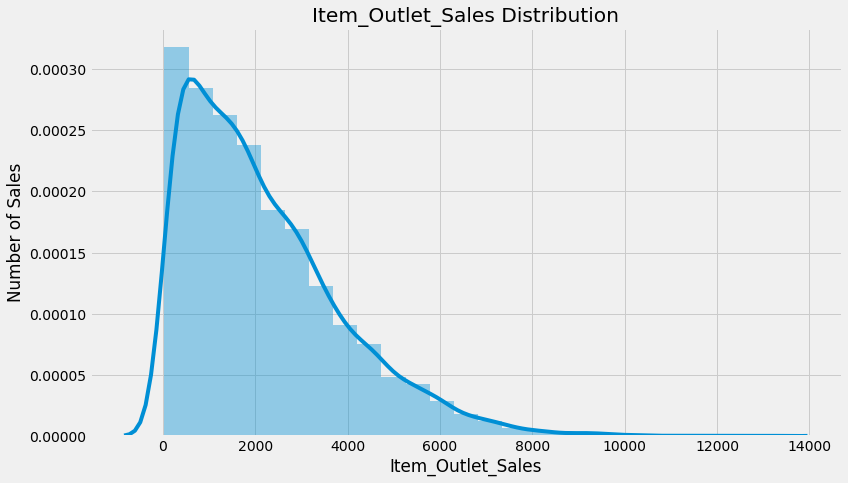

```python
plt.style.use('fivethirtyeight')
plt.figure(figsize=(12,7))
sns.distplot(data.Item_Outlet_Sales, bins = 25)
plt.ticklabel_format(style='plain', axis='x', scilimits=(0,1))
plt.xlabel("Item_Outlet_Sales")
plt.ylabel("Number of Sales")
plt.title("Item_Outlet_Sales Distribution")
```

```python
print ("Skew is:", data.Item_Outlet_Sales.skew())
print("Kurtosis: %f" % data.Item_Outlet_Sales.kurt())
```

```
Skew is: 1.1775306028542798
Kurtosis: 1.615877
```

We can see that our target variable is skewed to the right, towards the higher sales, with higher concentration on lower sales.

```python
numeric_features = data.select_dtypes(include=[np.number])
numeric_features.dtypes
```

```
Item_Weight                  float64
Item_Visibility              float64
Item_MRP                     float64
Outlet_Establishment_Year      int64
Item_Outlet_Sales            float64
dtype: object
```

```python
corr =numeric_features.corr()
corr
```

|  | Item_Weight | Item_Visibility | Item_MRP | Outlet_Establishment_Year | Item_Outlet_Sales |
| --- | --- | --- | --- | --- | --- |
| Item_Weight | 1.000000 | -0.014048 | 0.027141 | -0.011588 | 0.014123 |
| Item_Visibility | -0.014048 | 1.000000 | -0.001315 | -0.074834 | -0.128625 |
| Item_MRP | 0.027141 | -0.001315 | 1.000000 | 0.005020 | 0.567574 |
| Outlet_Establishment_Year | -0.011588 | -0.074834 | 0.005020 | 1.000000 | -0.049135 |
| Item_Outlet_Sales | 0.014123 | -0.128625 | 0.567574 | -0.049135 | 1.000000 |

```python
print(corr['Item_Outlet_Sales'].sort_values(ascending=False))
```

```
Item_Outlet_Sales            1.000000
Item_MRP                     0.567574
Item_Weight                  0.014123
Outlet_Establishment_Year   -0.049135
Item_Visibility             -0.128625
Name: Item_Outlet_Sales, dtype: float64
```

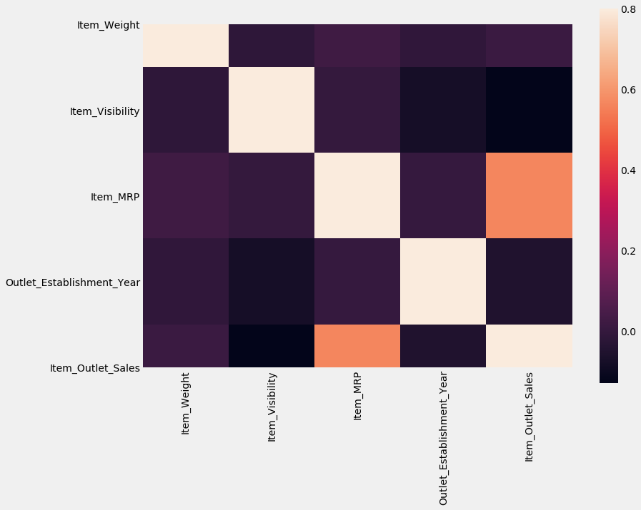

```python
#correlation matrix
f, ax = plt.subplots(figsize=(12, 9))
sns.heatmap(corr, vmax=.8, square=True);
```

For categorical variables, bar charts and frequency counts are the natural counterparts to histograms. Now is time to look at the variables that contain some insight on the assumptions previously made

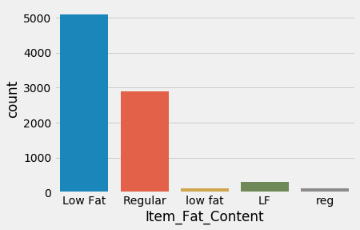

```python
sns.countplot(data.Item_Fat_Content)
```

For Item_Fat_Content there are two possible choices : “Low Fat” or “Regular”. However, in our data we have these two types of Fat writen in different manners. This must be corrected.

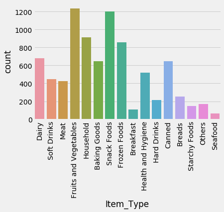

```python
sns.countplot(data.Item_Type)
plt.xticks(rotation=90)
```

Looking at the list of Item_Type we see there are sixteen different types. This is a high number of unique values for a categorical variable. Therefore we must try to think of a way to drastically reduce this number.

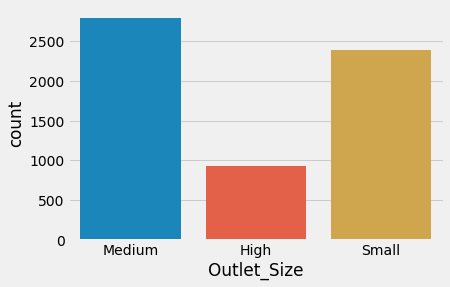

```python
sns.countplot(data.Outlet_Size)
```

There seems to be a low number of stores with size equals to “High”. Most of the existent stores seem to be either “Small” or “Medium”. It will be interesting to see how this variable relates to our target. If “High” size stores have better results as initially expected or due to this number distribution sales results might be similar.

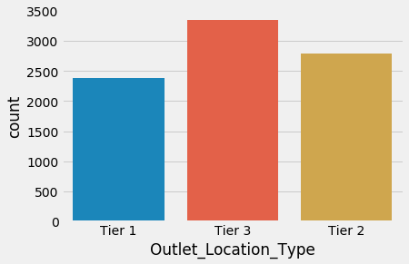

```python
sns.countplot(data.Outlet_Location_Type)
```

Bigmart appears to be a supermarket brand that is more present in “Small” to “Medium” size cities than in more densily populated locations.

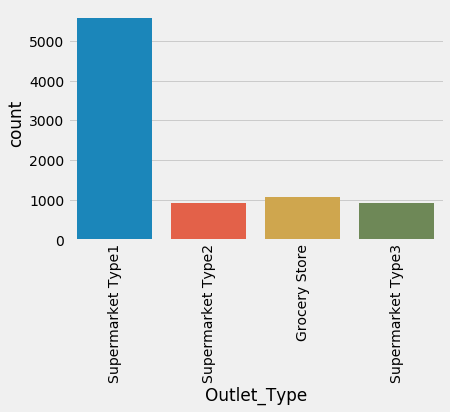

```python
sns.countplot(data.Outlet_Type)
plt.xticks(rotation=90)
```

It looks like Supermarket Type2 , Grocery Store and Supermarket Type3 all have low expression in this distribution. Maybe we can create a single category with all of the three. Nevertheless, before doing this we must see their impact in the Item_Outlet_Sales .

Firstly we individually analysed some of the existent features, now it is time to understand the relationship between our target variable and predictors as well as the relationship among predictors

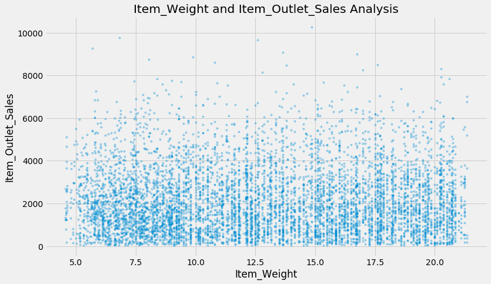

```python
plt.figure(figsize=(12,7))
plt.xlabel("Item_Weight")
plt.ylabel("Item_Outlet_Sales")
plt.title("Item_Weight and Item_Outlet_Sales Analysis")
plt.plot(data.Item_Weight, data["Item_Outlet_Sales"],'.', alpha = 0.3)
```

We saw previously that Item_Weight had a low correlation with our target variable. If we plot both features we can see that relationship.

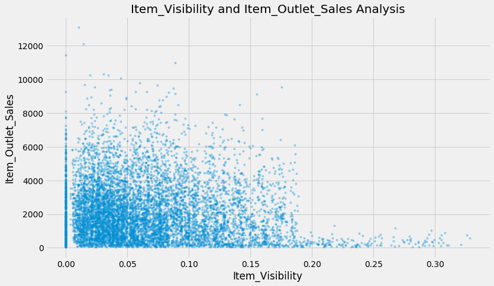

```python
plt.figure(figsize=(12,7))
plt.xlabel("Item_Visibility")
plt.ylabel("Item_Outlet_Sales")
plt.title("Item_Visibility and Item_Outlet_Sales Analysis")
plt.plot(data.Item_Visibility, data["Item_Outlet_Sales"],'.', alpha = 0.3)
```

Visibility in Store: The location of product in a store will impact sales. Ones which are right at entrance will catch the eye of customer first rather than the ones in back.

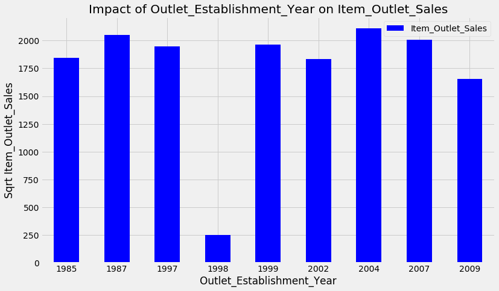

```python
Outlet_Establishment_Year_pivot = \
data.pivot_table(index='Outlet_Establishment_Year', values="Item_Outlet_Sales", aggfunc=np.median)
Outlet_Establishment_Year_pivot.plot(kind='bar', color='blue',figsize=(12,7))
plt.xlabel("Outlet_Establishment_Year")
plt.ylabel("Sqrt Item_Outlet_Sales")
plt.title("Impact of Outlet_Establishment_Year on Item_Outlet_Sales")
plt.xticks(rotation=0)
plt.show()
```

There seems to be no significant meaning between the year of store establishment and the sales for the items. 1998 has low values but thet might be due to the fact the few stores opened in that year.

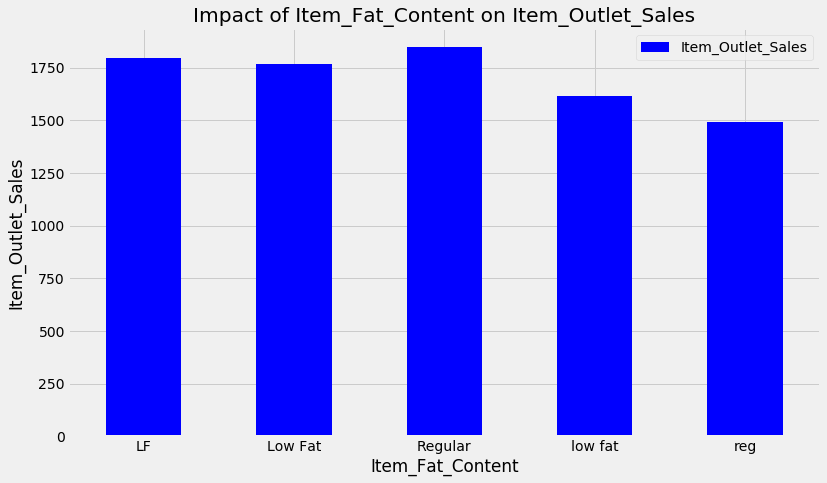

```python
Item_Fat_Content_pivot = \
data.pivot_table(index='Item_Fat_Content', values="Item_Outlet_Sales", aggfunc=np.median)
Item_Fat_Content_pivot.plot(kind='bar', color='blue',figsize=(12,7))
plt.xlabel("Item_Fat_Content")
plt.ylabel("Item_Outlet_Sales")
plt.title("Impact of Item_Fat_Content on Item_Outlet_Sales")
plt.xticks(rotation=0)
plt.show()
```

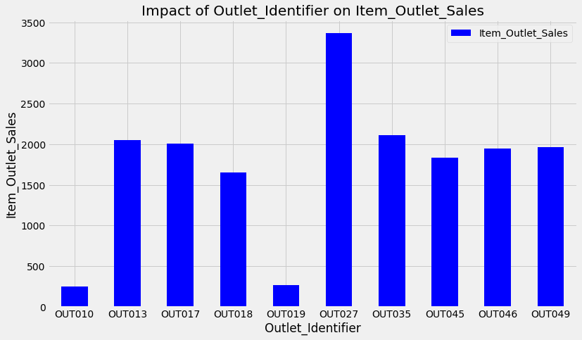

```python
Outlet_Identifier_pivot = \
data.pivot_table(index='Outlet_Identifier', values="Item_Outlet_Sales", aggfunc=np.median)
Outlet_Identifier_pivot.plot(kind='bar', color='blue',figsize=(12,7))
plt.xlabel("Outlet_Identifier")
plt.ylabel("Item_Outlet_Sales")
plt.title("Impact of Outlet_Identifier on Item_Outlet_Sales")
plt.xticks(rotation=0)
plt.show()
```

```python
data.pivot_table(values='Outlet_Type', columns='Outlet_Identifier',aggfunc=lambda x:x.mode())
```

| Outlet_Identifier | OUT010 | OUT013 | OUT017 | OUT018 | OUT019 | OUT027 | OUT035 | OUT045 | OUT046 | OUT049 |
| --- | --- | --- | --- | --- | --- | --- | --- | --- | --- | --- |
| Outlet_Type | Grocery Store | Supermarket Type1 | Supermarket Type1 | Supermarket Type2 | Grocery Store | Supermarket Type3 | Supermarket Type1 | Supermarket Type1 | Supermarket Type1 | Supermarket Type1 |

```python
data.pivot_table(values='Outlet_Type', columns='Outlet_Size',aggfunc=lambda x:x.mode())
```

| Outlet_Size | High | Medium | Small |
| --- | --- | --- | --- |
| Outlet_Type | Supermarket Type1 | Supermarket Type3 | Supermarket Type1 |

From the ten stores, two are Groceries whereas six are Supermarket Type1, one Supermarket Type2 and one Supermarket Type3. You can get this information from the pivot_tables below.

From the above bar chart, we see that thr groceries (“OUT010”, “OUT019”) have the lowest sales results which is expected followed by the Supermarket Type 2 (“OUT018”). Curiously, most stores are of type Supermarket Type1 of size “High” and do not have the best results. The best results belong to “Out027” which is a “Medium” size Supermarket Type 3.

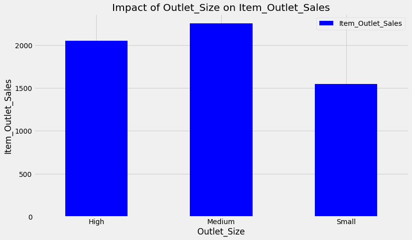

```python
Outlet_Size_pivot = \
data.pivot_table(index='Outlet_Size', values='Item_Outlet_Sales', aggfunc=np.median)
Outlet_Size_pivot.plot(kind='bar', color='blue',figsize=(12,7))
plt.xlabel("Outlet_Size")
plt.ylabel("Item_Outlet_Sales")
plt.title("Impact of Outlet_Size on Item_Outlet_Sales")
plt.xticks(rotation=0)
plt.show()
```

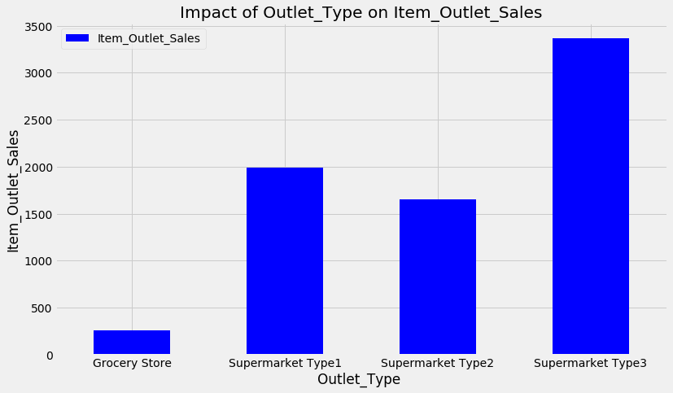

```python
Outlet_Type_pivot = \
data.pivot_table(index='Outlet_Type', values="Item_Outlet_Sales", aggfunc=np.median)
Outlet_Type_pivot.plot(kind='bar', color='blue',figsize=(12,7))
plt.xlabel("Outlet_Type ")
plt.ylabel("Item_Outlet_Sales")
plt.title("Impact of Outlet_Type on Item_Outlet_Sales")
plt.xticks(rotation=0)
plt.show()
```

From this analysis possibly it would be a good idea to creat a new feature that shows the sales ratio according to the store size.

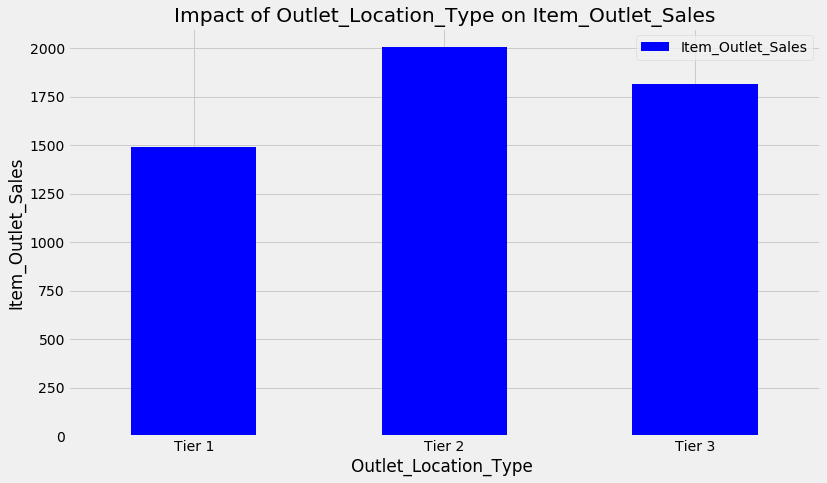

```python
Outlet_Location_Type_pivot = \
data.pivot_table(index='Outlet_Location_Type', values="Item_Outlet_Sales", aggfunc=np.median)
Outlet_Location_Type_pivot.plot(kind='bar', color='blue',figsize=(12,7))
plt.xlabel("Outlet_Location_Type ")
plt.ylabel("Item_Outlet_Sales")
plt.title("Impact of Outlet_Location_Type on Item_Outlet_Sales")
plt.xticks(rotation=0)
plt.show()
```

```python
data.pivot_table(values='Outlet_Location_Type', columns='Outlet_Type',aggfunc=lambda x:x.mode())
```

| Outlet_Type | Grocery Store | Supermarket Type1 | Supermarket Type2 | Supermarket Type3 |
| --- | --- | --- | --- | --- |
| Outlet_Location_Type | Tier 3 | Tier 2 | Tier 3 | Tier 3 |

Do Tier 1 cities have higher sales? This was one of the premisses we made in the start of this study. However, if we look at our results we see that in fact it is stores from Tier 2 cities that present the highest results, followed by Tier 3 cities and with Tier 1 cities with the lowest results of the three type of locations.

From the pivot_table it is easy to see that Tier2 and Tier3 cities are those that have highest representation of stores.

During our EDA we were able to take some conclusions regarding our first assumptions and the available data:

Regarding the variables which were thought to have high impact on the product’s sale price.

Item_Visibility does not have a high positive correlation as expected, quite the opposite. As well, there are no big variations in the sales due to theItem_Type . On the other hand, it was possible to see that the size, location and type of store could have a positive impact on sales.

If we look at variable Item_Identifer , we can see different groups of letters per each product such as ‘FD’ (Food), ‘DR’(Drinks) and ‘NC’ (Non-Consumable). From this we can create a new variable.

Regarding Item_Visibility there are items with the value zero. This does not make lot of sense, since this is indicating those items are not visible on the store.

Similar, Item_Weight and Outlet_Size seem to present NaN values.

Item_Fat_Content has vale “low fat” writen in different manners.

For Item_Type we try to create a new feature that does not have 16 unique values.

Outlet_Establishment_Year besides being a hidden category, its values vary from 1985 to 2009 . It must be converted to how old the store is to better see the impact on sales.

```python
#Check the percentage of null values per variable
data.isnull().sum()/data.shape[0]*100 #show values in percentage
```

```
Item_Identifier               0.000000
Item_Weight                  17.165317
Item_Fat_Content              0.000000
Item_Visibility               0.000000
Item_Type                     0.000000
Item_MRP                      0.000000
Outlet_Identifier             0.000000
Outlet_Establishment_Year     0.000000
Outlet_Size                  28.276428
Outlet_Location_Type          0.000000
Outlet_Type                   0.000000
Item_Outlet_Sales             0.000000
dtype: float64
```

```python
#aggfunc is mean by default! Ignores NaN by default
item_avg_weight = data.pivot_table(values='Item_Weight', index='Item_Identifier')
print(item_avg_weight.head())
```

```
                 Item_Weight
Item_Identifier
DRA12                 11.600
DRA24                 19.350
DRA59                  8.270
DRB01                  7.390
DRB13                  6.115
```

```python
data["Outlet_Size"] = data["Outlet_Size"].fillna(data["Outlet_Size"].mode()[0])
data["Item_Weight"] = data["Item_Weight"].fillna(np.nanmedian(data["Item_Weight"]))
#Check the percentage of null values per variable
data.isnull().sum()/data.shape[0]*100 #show values in percentage
```

```
Item_Identifier              0.0
Item_Weight                  0.0
Item_Fat_Content             0.0
Item_Visibility              0.0
Item_Type                    0.0
Item_MRP                     0.0
Outlet_Identifier            0.0
Outlet_Establishment_Year    0.0
Outlet_Size                  0.0
Outlet_Location_Type         0.0
Outlet_Type                  0.0
Item_Outlet_Sales            0.0
dtype: float64
```

```python
#Creates pivot table with Outlet_Type and the mean of #Item_Outlet_Sales. Agg function is by default mean()
data.pivot_table(values='Item_Outlet_Sales', columns='Outlet_Type')
```

| Outlet_Type | Grocery Store | Supermarket Type1 | Supermarket Type2 | Supermarket Type3 |
| --- | --- | --- | --- | --- |
| Item_Outlet_Sales | 339.8285 | 2316.181148 | 1995.498739 | 3694.038558 |

In our exploration we questioned “Is it viable to combine Supermarket Type 2 and Type 3?” Let’s check.

As observed by the results below, the average product sales are significantly different so we leave as is.

```python
print ('Original #zeros: %d'%sum(data['Item_Visibility'] == 0))
data['Item_Visibility']=data['Item_Visibility'].replace(0,data['Item_Visibility'].mean())
print ('Final #zeros: %d'%sum(data['Item_Visibility'] == 0))
```

```
Original #zeros: 526
Final #zeros: 0
```

```python
#Remember the data is from 2013
data['Outlet_Years'] = 2013 - data['Outlet_Establishment_Year']
data['Outlet_Years'].describe()
```

```
count    8523.000000
mean       15.168133
std         8.371760
min         4.000000
25%         9.000000
50%        14.000000
75%        26.000000
max        28.000000
Name: Outlet_Years, dtype: float64
```

We talked about using how long has been working instead of the date of start. Remember that the data we have is from 2013. Thus we must consider this year into our calculations-

```python
#Get the first two characters of ID:
data['Item_Type_Combined'] = data['Item_Identifier'].apply(lambda x: x[0:2])
#Rename them to more intuitive categories:
data['Item_Type_Combined'] = data['Item_Type_Combined'].map({'FD':'Food','NC':'Non-Consumable','DR':'Drinks'})
data['Item_Type_Combined'].value_counts()
```

```
Food              6125
Non-Consumable    1599
Drinks             799
Name: Item_Type_Combined, dtype: int64
```

```python
#Change categories of low fat:
print('Original Categories:')
print(data['Item_Fat_Content'].value_counts())
print('\nModified Categories:')
data['Item_Fat_Content'] = data['Item_Fat_Content'].replace({'LF':'Low Fat','low fat':'Low Fat'})
print(data['Item_Fat_Content'].value_counts())
```

```
Original Categories:
Low Fat    5089
Regular    2889
LF          316
reg         117
low fat     112
Name: Item_Fat_Content, dtype: int64

Modified Categories:
Low Fat    5517
Regular    2889
reg         117
Name: Item_Fat_Content, dtype: int64
```

```python
#Mark non-consumables as separate category in low_fat:
data.loc[data['Item_Type_Combined']=="Non-Consumable",'Item_Fat_Content'] = "Non-Edible"
data['Item_Fat_Content'].value_counts()
```

```
Low Fat       3918
Regular       2889
Non-Edible    1599
reg            117
Name: Item_Fat_Content, dtype: int64
```

```python
#Import library:
from sklearn.preprocessing import LabelEncoder
le = LabelEncoder()
#New variable for outlet
data['Outlet'] = le.fit_transform(data['Outlet_Identifier'])
var_mod = ['Item_Fat_Content','Outlet_Location_Type','Outlet_Size','Item_Type_Combined','Outlet_Type','Outlet']
for i in var_mod:
    data[i] = le.fit_transform(data[i])
```

```python
#Dummy Variables:
data = pd.get_dummies(data, columns =['Item_Fat_Content','Outlet_Location_Type','Outlet_Size','Outlet_Type','Item_Type_Combined','Outlet'])
data.dtypes
```

```
Item_Identifier               object
Item_Weight                  float64
Item_Visibility              float64
Item_Type                     object
Item_MRP                     float64
Outlet_Identifier             object
Outlet_Establishment_Year      int64
Item_Outlet_Sales            float64
Outlet_Years                   int64
Item_Fat_Content_0             uint8
Item_Fat_Content_1             uint8
Item_Fat_Content_2             uint8
Item_Fat_Content_3             uint8
Outlet_Location_Type_0         uint8
Outlet_Location_Type_1         uint8
Outlet_Location_Type_2         uint8
Outlet_Size_0                  uint8
Outlet_Size_1                  uint8
Outlet_Size_2                  uint8
Outlet_Type_0                  uint8
Outlet_Type_1                  uint8
Outlet_Type_2                  uint8
Outlet_Type_3                  uint8
Item_Type_Combined_0           uint8
Item_Type_Combined_1           uint8
Item_Type_Combined_2           uint8
Outlet_0                       uint8
Outlet_1                       uint8
Outlet_2                       uint8
Outlet_3                       uint8
Outlet_4                       uint8
Outlet_5                       uint8
Outlet_6                       uint8
Outlet_7                       uint8
Outlet_8                       uint8
Outlet_9                       uint8
dtype: object
```

```python
data.shape
```

```
(8523, 36)
```

```python
# Split Train and Test and check shape
def SplitTrainAndTest(data, TrainRate, TargetAtt):
    # gets a random TrainDataRate % of the entire set
    training = data.sample(frac=TrainRate, random_state=1)
    # gets the left out portion of the dataset
    testing = data.loc[~data.index.isin(training.index)]

    data_train = training.drop(TargetAtt, 1)
    label_train = training[[TargetAtt]]
    data_test = testing.drop(TargetAtt, 1)
    label_test = testing[[TargetAtt]]

    PrintTrainTestInfo(data_train, label_train, data_test, label_test)
    return data_train, label_train, data_test, label_test

def PrintTrainTestInfo(data_train, label_train, data_test, label_test):
  print("Train shape : ", data_train.shape)
  print("Test shape : ", data_test.shape)
```

```python
from sklearn.preprocessing import LabelEncoder
EncoderAttList = ["Item_Type"]

data_encoder = data.copy()
for att in EncoderAttList:
  data_encoder[att] = LabelEncoder().fit_transform(data_encoder[att])

data_encoder = data_encoder.drop(['Item_Identifier', 'Outlet_Identifier'], 1)

display(data_encoder.info())
display(data_encoder.head(10))
```

```
<class 'pandas.core.frame.DataFrame'>
RangeIndex: 8523 entries, 0 to 8522
Data columns (total 34 columns):
Item_Weight                  8523 non-null float64
Item_Visibility              8523 non-null float64
Item_Type                    8523 non-null int32
Item_MRP                     8523 non-null float64
Outlet_Establishment_Year    8523 non-null int64
Item_Outlet_Sales            8523 non-null float64
Outlet_Years                 8523 non-null int64
Item_Fat_Content_0           8523 non-null uint8
Item_Fat_Content_1           8523 non-null uint8
Item_Fat_Content_2           8523 non-null uint8
Item_Fat_Content_3           8523 non-null uint8
Outlet_Location_Type_0       8523 non-null uint8
Outlet_Location_Type_1       8523 non-null uint8
Outlet_Location_Type_2       8523 non-null uint8
Outlet_Size_0                8523 non-null uint8
Outlet_Size_1                8523 non-null uint8
Outlet_Size_2                8523 non-null uint8
Outlet_Type_0                8523 non-null uint8
Outlet_Type_1                8523 non-null uint8
Outlet_Type_2                8523 non-null uint8
Outlet_Type_3                8523 non-null uint8
Item_Type_Combined_0         8523 non-null uint8
Item_Type_Combined_1         8523 non-null uint8
Item_Type_Combined_2         8523 non-null uint8
Outlet_0                     8523 non-null uint8
Outlet_1                     8523 non-null uint8
Outlet_2                     8523 non-null uint8
Outlet_3                     8523 non-null uint8
Outlet_4                     8523 non-null uint8
Outlet_5                     8523 non-null uint8
Outlet_6                     8523 non-null uint8
Outlet_7                     8523 non-null uint8
Outlet_8                     8523 non-null uint8
Outlet_9                     8523 non-null uint8
dtypes: float64(4), int32(1), int64(2), uint8(27)
memory usage: 657.7 KB
```

```
None
```

|  | Item_Weight | Item_Visibility | Item_Type | Item_MRP | Outlet_Establishment_Year | Item_Outlet_Sales | Outlet_Years | Item_Fat_Content_0 | Item_Fat_Content_1 | Item_Fat_Content_2 | ... | Outlet_0 | Outlet_1 | Outlet_2 | Outlet_3 | Outlet_4 | Outlet_5 | Outlet_6 | Outlet_7 | Outlet_8 | Outlet_9 |
| --- | --- | --- | --- | --- | --- | --- | --- | --- | --- | --- | --- | --- | --- | --- | --- | --- | --- | --- | --- | --- | --- |
| 0 | 9.300 | 0.016047 | 4 | 249.8092 | 1999 | 3735.1380 | 14 | 1 | 0 | 0 | ... | 0 | 0 | 0 | 0 | 0 | 0 | 0 | 0 | 0 | 1 |
| 1 | 5.920 | 0.019278 | 14 | 48.2692 | 2009 | 443.4228 | 4 | 0 | 0 | 1 | ... | 0 | 0 | 0 | 1 | 0 | 0 | 0 | 0 | 0 | 0 |
| 2 | 17.500 | 0.016760 | 10 | 141.6180 | 1999 | 2097.2700 | 14 | 1 | 0 | 0 | ... | 0 | 0 | 0 | 0 | 0 | 0 | 0 | 0 | 0 | 1 |
| 3 | 19.200 | 0.066132 | 6 | 182.0950 | 1998 | 732.3800 | 15 | 0 | 0 | 1 | ... | 1 | 0 | 0 | 0 | 0 | 0 | 0 | 0 | 0 | 0 |
| 4 | 8.930 | 0.066132 | 9 | 53.8614 | 1987 | 994.7052 | 26 | 0 | 1 | 0 | ... | 0 | 1 | 0 | 0 | 0 | 0 | 0 | 0 | 0 | 0 |
| 5 | 10.395 | 0.066132 | 0 | 51.4008 | 2009 | 556.6088 | 4 | 0 | 0 | 1 | ... | 0 | 0 | 0 | 1 | 0 | 0 | 0 | 0 | 0 | 0 |
| 6 | 13.650 | 0.012741 | 13 | 57.6588 | 1987 | 343.5528 | 26 | 0 | 0 | 1 | ... | 0 | 1 | 0 | 0 | 0 | 0 | 0 | 0 | 0 | 0 |
| 7 | 12.600 | 0.127470 | 13 | 107.7622 | 1985 | 4022.7636 | 28 | 1 | 0 | 0 | ... | 0 | 0 | 0 | 0 | 0 | 1 | 0 | 0 | 0 | 0 |
| 8 | 16.200 | 0.016687 | 5 | 96.9726 | 2002 | 1076.5986 | 11 | 0 | 0 | 1 | ... | 0 | 0 | 0 | 0 | 0 | 0 | 0 | 1 | 0 | 0 |
| 9 | 19.200 | 0.094450 | 5 | 187.8214 | 2007 | 4710.5350 | 6 | 0 | 0 | 1 | ... | 0 | 0 | 1 | 0 | 0 | 0 | 0 | 0 | 0 | 0 |

10 rows × 34 columns

```python
data_train, label_train, data_test, label_test = SplitTrainAndTest(data_encoder, 0.7, 'Item_Outlet_Sales')
FeatureList = data_train.columns.to_list()
TargetAtt = 'Item_Outlet_Sales'
print(FeatureList)
```

```
Train shape :  (5966, 33)
Test shape :  (2557, 33)
['Item_Weight', 'Item_Visibility', 'Item_Type', 'Item_MRP', 'Outlet_Establishment_Year', 'Outlet_Years', 'Item_Fat_Content_0', 'Item_Fat_Content_1', 'Item_Fat_Content_2', 'Item_Fat_Content_3', 'Outlet_Location_Type_0', 'Outlet_Location_Type_1', 'Outlet_Location_Type_2', 'Outlet_Size_0', 'Outlet_Size…
```

```python
from sklearn.linear_model import LinearRegression
from sklearn.metrics import mean_squared_error
from sklearn.metrics import r2_score

LRModel = LinearRegression(normalize=True)
Model = LRModel

Model.fit(data_train[FeatureList], label_train)
# model evaluation for training set
label_train_predict = Model.predict(data_train[FeatureList])
rmse = (np.sqrt(mean_squared_error(label_train, label_train_predict)))
r2 = r2_score(label_train, label_train_predict)

print("The model performance for training set")
print("--------------------------------------")
print('RMSE is {}'.format(rmse))
print('R2 score is {}'.format(r2))
print("\n")

# model evaluation for testing set
label_test_predict = Model.predict(data_test[FeatureList])
rmse = (np.sqrt(mean_squared_error(label_test, label_test_predict)))
r2 = r2_score(label_test, label_test_predict)

print("The model performance for testing set")
print("--------------------------------------")
print('RMSE is {}'.format(rmse))
print('R2 score is {}'.format(r2))
print("\n")
```

```
The model performance for training set
--------------------------------------
RMSE is 1120.9176220061886
R2 score is 0.5649000367324881


The model performance for testing set
--------------------------------------
RMSE is 1144.0663609435828
R2 score is 0.558974291926713
```

```python
PredictDF = data_test[FeatureList].copy()
PredictDF[TargetAtt] = label_test
PredictDF["Predict"] = label_test_predict
PredictDF = PredictDF.reset_index(drop=False)

display(PredictDF.head())
```

|  | index | Item_Weight | Item_Visibility | Item_Type | Item_MRP | Outlet_Establishment_Year | Outlet_Years | Item_Fat_Content_0 | Item_Fat_Content_1 | Item_Fat_Content_2 | ... | Outlet_2 | Outlet_3 | Outlet_4 | Outlet_5 | Outlet_6 | Outlet_7 | Outlet_8 | Outlet_9 | Item_Outlet_Sales | Predict |
| --- | --- | --- | --- | --- | --- | --- | --- | --- | --- | --- | --- | --- | --- | --- | --- | --- | --- | --- | --- | --- | --- |
| 0 | 0 | 9.30 | 0.016047 | 4 | 249.8092 | 1999 | 14 | 1 | 0 | 0 | ... | 0 | 0 | 0 | 0 | 0 | 0 | 0 | 1 | 3735.1380 | 4016.0 |
| 1 | 2 | 17.50 | 0.016760 | 10 | 141.6180 | 1999 | 14 | 1 | 0 | 0 | ... | 0 | 0 | 0 | 0 | 0 | 0 | 0 | 1 | 2097.2700 | 2352.0 |
| 2 | 8 | 16.20 | 0.016687 | 5 | 96.9726 | 2002 | 11 | 0 | 0 | 1 | ... | 0 | 0 | 0 | 0 | 0 | 1 | 0 | 0 | 1076.5986 | 1632.0 |
| 3 | 14 | 16.35 | 0.068024 | 6 | 196.4426 | 1987 | 26 | 1 | 0 | 0 | ... | 0 | 0 | 0 | 0 | 0 | 0 | 0 | 0 | 1977.4260 | 3168.0 |
| 4 | 15 | 9.00 | 0.069089 | 2 | 56.3614 | 1997 | 16 | 0 | 0 | 1 | ... | 0 | 0 | 0 | 0 | 0 | 0 | 1 | 0 | 1547.3192 | 992.0 |

5 rows × 36 columns

```python
from sklearn.tree import DecisionTreeRegressor
DTModel = DecisionTreeRegressor(max_depth=15, min_samples_leaf=100)
Model = DTModel

Model.fit(data_train[FeatureList], label_train)
# model evaluation for training set
label_train_predict = Model.predict(data_train[FeatureList])
rmse = (np.sqrt(mean_squared_error(label_train, label_train_predict)))
r2 = r2_score(label_train, label_train_predict)

print("The model performance for training set")
print("--------------------------------------")
print('RMSE is {}'.format(rmse))
print('R2 score is {}'.format(r2))
print("\n")

# model evaluation for testing set
label_test_predict = Model.predict(data_test[FeatureList])
rmse = (np.sqrt(mean_squared_error(label_test, label_test_predict)))
r2 = r2_score(label_test, label_test_predict)

print("The model performance for testing set")
print("--------------------------------------")
print('RMSE is {}'.format(rmse))
print('R2 score is {}'.format(r2))
print("\n")
```

```
The model performance for training set
--------------------------------------
RMSE is 1059.6692730036987
R2 score is 0.6111497918107782


The model performance for testing set
--------------------------------------
RMSE is 1102.0288371483964
R2 score is 0.590788913298389
```

```python
from sklearn.ensemble import RandomForestRegressor
RFModel = RandomForestRegressor(n_estimators=100,max_depth=8, min_samples_leaf=150, random_state=123)
Model = RFModel

Model.fit(data_train[FeatureList], label_train)
# model evaluation for training set
label_train_predict = Model.predict(data_train[FeatureList])
rmse = (np.sqrt(mean_squared_error(label_train, label_train_predict)))
r2 = r2_score(label_train, label_train_predict)

print("The model performance for training set")
print("--------------------------------------")
print('RMSE is {}'.format(rmse))
print('R2 score is {}'.format(r2))
print("\n")

# model evaluation for testing set
label_test_predict = Model.predict(data_test[FeatureList])
rmse = (np.sqrt(mean_squared_error(label_test, label_test_predict)))
r2 = r2_score(label_test, label_test_predict)

print("The model performance for testing set")
print("--------------------------------------")
print('RMSE is {}'.format(rmse))
print('R2 score is {}'.format(r2))
print("\n")
```

```
The model performance for training set
--------------------------------------
RMSE is 1082.7748756313142
R2 score is 0.5940075166392311


The model performance for testing set
--------------------------------------
RMSE is 1100.4067209004963
R2 score is 0.5919926920080002
```

```python
def XGBRegressorApporach(data_train, label_train, data_test, label_test, FeatureList, TargetAtt):
  from sklearn.metrics import mean_squared_error
  from sklearn.metrics import r2_score
  from xgboost import XGBRegressor

  XGBModel = XGBRegressor()
  XGBModel.fit(data_train[FeatureList], label_train)

  # model evaluation for training set
  label_train_predict = XGBModel.predict(data_train[FeatureList])
  rmse = (np.sqrt(mean_squared_error(label_train, label_train_predict)))
  r2 = r2_score(label_train, label_train_predict)

  print("The model performance for training set")
  print("--------------------------------------")
  print('RMSE is {}'.format(rmse))
  print('R2 score is {}'.format(r2))
  print("\n")

  # model evaluation for testing set
  label_test_predict = XGBModel.predict(data_test[FeatureList])
  rmse = (np.sqrt(mean_squared_error(label_test, label_test_predict)))
  r2 = r2_score(label_test, label_test_predict)

  print("The model performance for testing set")
  print("--------------------------------------")
  print('RMSE is {}'.format(rmse))
  print('R2 score is {}'.format(r2))
  print("\n")

  PredictDF = data_test[FeatureList].copy()
  PredictDF[TargetAtt] = label_test
  PredictDF["Predict"] = label_test_predict
  PredictDF = PredictDF.reset_index(drop=False)

  print("The the predict table result : ")
  print("--------------------------------------")
  display(PredictDF.head(10))

  return XGBModel, PredictDF

def PredictXGBRegressor(XGBModel, FeatureSample, TrueLabel = ""):
  if isinstance(FeatureSample, pd.Series):
    FeatureSample = [FeatureSample]

  print(FeatureSample)

  label_predict = XGBModel.predict(FeatureSample)


  DirectPredictDF = FeatureSample.copy()
  DirectPredictDF["LabelTest"] = list(TrueLabel)
  DirectPredictDF["Predict"] = label_predict
  DirectPredictDF = DirectPredictDF.reset_index(drop=False)

  print("\n")
  print("The the predict table result : ")
  print("--------------------------------------")
  display(DirectPredictDF.head(10))

  return DirectPredictDF
```

```python
XGBModel, PredictDF = XGBRegressorApporach(data_train, label_train, data_test, label_test, FeatureList, TargetAtt)
```

```
[21:52:07] WARNING: C:/Jenkins/workspace/xgboost-win64_release_0.90/src/objective/regression_obj.cu:152: reg:linear is now deprecated in favor of reg:squarederror.
The model performance for training set
--------------------------------------
RMSE is 1026.4585644002298
R2 score is 0.6351414747550952


The model performance for testing set
--------------------------------------
RMSE is 1086.398975847106
R2 score is 0.6023141226585296


The the predict table result :
--------------------------------------
```

|  | index | Item_Weight | Item_Visibility | Item_Type | Item_MRP | Outlet_Establishment_Year | Outlet_Years | Item_Fat_Content_0 | Item_Fat_Content_1 | Item_Fat_Content_2 | ... | Outlet_2 | Outlet_3 | Outlet_4 | Outlet_5 | Outlet_6 | Outlet_7 | Outlet_8 | Outlet_9 | Item_Outlet_Sales | Predict |
| --- | --- | --- | --- | --- | --- | --- | --- | --- | --- | --- | --- | --- | --- | --- | --- | --- | --- | --- | --- | --- | --- |
| 0 | 0 | 9.30 | 0.016047 | 4 | 249.8092 | 1999 | 14 | 1 | 0 | 0 | ... | 0 | 0 | 0 | 0 | 0 | 0 | 0 | 1 | 3735.1380 | 3898.450928 |
| 1 | 2 | 17.50 | 0.016760 | 10 | 141.6180 | 1999 | 14 | 1 | 0 | 0 | ... | 0 | 0 | 0 | 0 | 0 | 0 | 0 | 1 | 2097.2700 | 2221.359619 |
| 2 | 8 | 16.20 | 0.016687 | 5 | 96.9726 | 2002 | 11 | 0 | 0 | 1 | ... | 0 | 0 | 0 | 0 | 0 | 1 | 0 | 0 | 1076.5986 | 1500.988525 |
| 3 | 14 | 16.35 | 0.068024 | 6 | 196.4426 | 1987 | 26 | 1 | 0 | 0 | ... | 0 | 0 | 0 | 0 | 0 | 0 | 0 | 0 | 1977.4260 | 3209.877930 |
| 4 | 15 | 9.00 | 0.069089 | 2 | 56.3614 | 1997 | 16 | 0 | 0 | 1 | ... | 0 | 0 | 0 | 0 | 0 | 0 | 1 | 0 | 1547.3192 | 875.161865 |
| 5 | 18 | 12.60 | 0.034238 | 7 | 113.2834 | 1985 | 28 | 1 | 0 | 0 | ... | 0 | 0 | 0 | 1 | 0 | 0 | 0 | 0 | 2303.6680 | 3150.006104 |
| 6 | 20 | 18.85 | 0.138190 | 13 | 250.8724 | 1987 | 26 | 0 | 0 | 1 | ... | 0 | 0 | 0 | 0 | 0 | 0 | 0 | 0 | 3775.0860 | 3889.281250 |
| 7 | 23 | 12.60 | 0.057557 | 0 | 107.6938 | 1985 | 28 | 1 | 0 | 0 | ... | 0 | 0 | 1 | 0 | 0 | 0 | 0 | 0 | 214.3876 | 293.027435 |
| 8 | 24 | 13.85 | 0.025896 | 5 | 165.0210 | 1997 | 16 | 0 | 0 | 1 | ... | 0 | 0 | 0 | 0 | 0 | 0 | 1 | 0 | 4078.0250 | 2709.084229 |
| 9 | 27 | 11.65 | 0.019356 | 7 | 39.1164 | 1987 | 26 | 1 | 0 | 0 | ... | 0 | 0 | 0 | 0 | 0 | 0 | 0 | 0 | 308.9312 | 686.943604 |

10 rows × 36 columns

```python
def LGBMRegressorApporach(data_train, label_train, data_test, label_test, FeatureList, TargetAtt):
  from sklearn.metrics import mean_squared_error
  from sklearn.metrics import r2_score
  import lightgbm as lgb

  LGBMModel = lgb.LGBMRegressor()
  LGBMModel.fit(data_train[FeatureList], label_train)

  # model evaluation for training set
  label_train_predict = LGBMModel.predict(data_train[FeatureList])
  rmse = (np.sqrt(mean_squared_error(label_train, label_train_predict)))
  r2 = r2_score(label_train, label_train_predict)

  print("The model performance for training set")
  print("--------------------------------------")
  print('RMSE is {}'.format(rmse))
  print('R2 score is {}'.format(r2))
  print("\n")

  # model evaluation for testing set
  label_test_predict = LGBMModel.predict(data_test[FeatureList])
  rmse = (np.sqrt(mean_squared_error(label_test, label_test_predict)))
  r2 = r2_score(label_test, label_test_predict)

  print("The model performance for testing set")
  print("--------------------------------------")
  print('RMSE is {}'.format(rmse))
  print('R2 score is {}'.format(r2))
  print("\n")

  PredictDF = data_test[FeatureList].copy()
  PredictDF[TargetAtt] = label_test
  PredictDF["Predict"] = label_test_predict
  PredictDF = PredictDF.reset_index(drop=False)

  print("The the predict table result : ")
  print("--------------------------------------")
  display(PredictDF.head(10))

  return LGBMModel, PredictDF

def PredictLGBMRegressor(LGBMModel, FeatureSample, TrueLabel = ""):
  if isinstance(FeatureSample, pd.Series):
    FeatureSample = [FeatureSample]

  print(FeatureSample)

  label_predict = LGBMModel.predict(FeatureSample)


  DirectPredictDF = FeatureSample.copy()
  DirectPredictDF["LabelTest"] = list(TrueLabel)
  DirectPredictDF["Predict"] = label_predict
  DirectPredictDF = DirectPredictDF.reset_index(drop=False)

  print("\n")
  print("The the predict table result : ")
  print("--------------------------------------")
  display(DirectPredictDF.head(10))

  return DirectPredictDF
```

```python
pip install lightgbm
```

```python
LGBMModel, PredictDF = LGBMRegressorApporach(data_train, label_train, data_test, label_test, FeatureList, TargetAtt)
```

```
The model performance for training set
--------------------------------------
RMSE is 875.1532362733373
R2 score is 0.7347778084691572


The model performance for testing set
--------------------------------------
RMSE is 1103.7693069878824
R2 score is 0.5894953319581073


The the predict table result :
--------------------------------------
```

|  | index | Item_Weight | Item_Visibility | Item_Type | Item_MRP | Outlet_Establishment_Year | Outlet_Years | Item_Fat_Content_0 | Item_Fat_Content_1 | Item_Fat_Content_2 | ... | Outlet_2 | Outlet_3 | Outlet_4 | Outlet_5 | Outlet_6 | Outlet_7 | Outlet_8 | Outlet_9 | Item_Outlet_Sales | Predict |
| --- | --- | --- | --- | --- | --- | --- | --- | --- | --- | --- | --- | --- | --- | --- | --- | --- | --- | --- | --- | --- | --- |
| 0 | 0 | 9.30 | 0.016047 | 4 | 249.8092 | 1999 | 14 | 1 | 0 | 0 | ... | 0 | 0 | 0 | 0 | 0 | 0 | 0 | 1 | 3735.1380 | 4359.689835 |
| 1 | 2 | 17.50 | 0.016760 | 10 | 141.6180 | 1999 | 14 | 1 | 0 | 0 | ... | 0 | 0 | 0 | 0 | 0 | 0 | 0 | 1 | 2097.2700 | 2058.257360 |
| 2 | 8 | 16.20 | 0.016687 | 5 | 96.9726 | 2002 | 11 | 0 | 0 | 1 | ... | 0 | 0 | 0 | 0 | 0 | 1 | 0 | 0 | 1076.5986 | 1501.331377 |
| 3 | 14 | 16.35 | 0.068024 | 6 | 196.4426 | 1987 | 26 | 1 | 0 | 0 | ... | 0 | 0 | 0 | 0 | 0 | 0 | 0 | 0 | 1977.4260 | 2938.880478 |
| 4 | 15 | 9.00 | 0.069089 | 2 | 56.3614 | 1997 | 16 | 0 | 0 | 1 | ... | 0 | 0 | 0 | 0 | 0 | 0 | 1 | 0 | 1547.3192 | 843.346755 |
| 5 | 18 | 12.60 | 0.034238 | 7 | 113.2834 | 1985 | 28 | 1 | 0 | 0 | ... | 0 | 0 | 0 | 1 | 0 | 0 | 0 | 0 | 2303.6680 | 3256.516532 |
| 6 | 20 | 18.85 | 0.138190 | 13 | 250.8724 | 1987 | 26 | 0 | 0 | 1 | ... | 0 | 0 | 0 | 0 | 0 | 0 | 0 | 0 | 3775.0860 | 3361.693777 |
| 7 | 23 | 12.60 | 0.057557 | 0 | 107.6938 | 1985 | 28 | 1 | 0 | 0 | ... | 0 | 0 | 1 | 0 | 0 | 0 | 0 | 0 | 214.3876 | 245.229397 |
| 8 | 24 | 13.85 | 0.025896 | 5 | 165.0210 | 1997 | 16 | 0 | 0 | 1 | ... | 0 | 0 | 0 | 0 | 0 | 0 | 1 | 0 | 4078.0250 | 2732.693556 |
| 9 | 27 | 11.65 | 0.019356 | 7 | 39.1164 | 1987 | 26 | 1 | 0 | 0 | ... | 0 | 0 | 0 | 0 | 0 | 0 | 0 | 0 | 308.9312 | 526.094768 |

10 rows × 36 columns